# P4 Informe

5/11/2021

## Estudio sobre los factores que podrían ocasionar Hipertensión arterial en las personas

## *————————————————————————————————–*

Objetivo General:

- Analizar los patrones y características que tienen las personas las cuales padecen de Hipertensión Arterial, para encontrar factores similares en ellos que puedan ayudar a la prevención de esta enfermedad en otras personas

Objetivos Específicos:

- Determinar las características más resultantes de las personas que tienen hipertensión arterial.
- Analizar el índice de masa corporal (IMC) a través de un análisis descriptivo.
- Analizar la relación existente entre la variable perímetro abdominal vs Índice de masa corporal.

## *————————————————————————————————–*

**Base de datos utilizada:**

- Fue extraído del [INEI](http://iinei.inei.gob.pe/microdatos/Consulta_por_Encuesta.asp) Encuesta Demográfica y de Salud Familiar – ENDES. Cuenta con 34,403 observaciones y 19 variables. Además contiene 25.22% de datos faltantes.
- Por Tratarse de un estudio clínico y de predicción se busca un alto nivel de confianza con respecto en los indicadores puntuales de la muestra, por otra parte los datos de la variable IMC no se encuentran dispersos, como se puede evidenciar en la gráfica boxplot, los datos se encuentran agrupados en la caja con un rago intercuartílico de 6 unidades aproximadamente. sucede lo mismo con El consumo de frutas por semana.Tomando en cuenta estas dos consideraciones se decidió trabajar con un Nivel de confianza de 95% y una significancia $\alpha = 0.05$.

## *————————————————————————————————–*

**Variables:**

| Pregunta | Variable | Tipo de Variable | Restricciones |
| --- | --- | --- | --- |
| Sexo de la persona | Sexo | Nominal | Hombre o Mujer |
| Edad de la persona | Edad | Ordinal | De 15 a 97 |
| ¿ La persona tiene Presión arterial alta ? | Hipertensión arterial | Nominal | Si o No |
| ¿ La persona tiene Diabetes ? | Diabetes | Nominal | Si o No |
| ¿ La persona fuma ? | Fumador | Nominal | Si o No |
| ¿ La persona consume frutas ? | Consumo_frutas | Nominal | Si o No |
| ¿ Cuantos días consumió frutas en la semana ? | Cantidad_fruta_consumida | Ordinal | 1:7 |
| ¿ La persona consume jugo de frutas ? | Consumo_jugo | Nominal | Si o No |
| ¿ Cuantos días consumió jugo de frutas en la semana ? | Cantidad_jugo | Ordinal | 1:7 |
| ¿ La persona consume verduras ? | Consumo_verduras | Nominal | Si o No |
| ¿ Cuantos días consumió verduras en la semana ? | Cantidad_verduras | Ordinal | 1:7 |
| ¿ En los Últimos 14 días ha sentido molestias o problemas como: Poco apetito/comer en exceso ? | Desorden_Alimenticio | Nominal | Si o No |
| Peso de la persona en Kg | Peso (Kg) | Ordinal |  |
| Talla de la persona en cm | Talla (Cm) | Ordinal |  |
| Primera medición presión arterial sistólica | P1S | Ordinal |  |
| Primera medición presión arterial diastólica | P1D | Ordinal |  |
| Segunda medición presión arterial sistólica | P2D | Ordinal |  |
| Segunda medición presión arterial diastólica | P2D | Ordinal |  |
| Perímetro abdominal | Perimetro_abdominal_(cm) | Ordinal |  |

## *————————————————————————————————–*

# IMC

- IMC (indice de masa corporal) y , esta variable fue obtenida a partir de las variables peso y talla de nuestra base de datos, la importancia de esta variable en nuestro análisis se fundamenta, según la Revista Venezolana de Endocrinóloga y Metabolismo, y también según lo demuestra nuestro gráfico boxplot que relaciona ambas variables, en la relación que esta condición médica guarda con una hipertensión arterial, considerándose un factor de riesgo para dicha condición clínica.

$$IMC=peso/altura^2$$

```
##    Min. 1st Qu.  Median    Mean 3rd Qu.    Max.    NA's
##   12.76   23.74   26.69   27.15   29.93   62.41   11995
```

- Media

```
## [1] 27.15231
```

- Mediana

```
## [1] 26.69
```

- IQR

```
## [1] 6.19
```

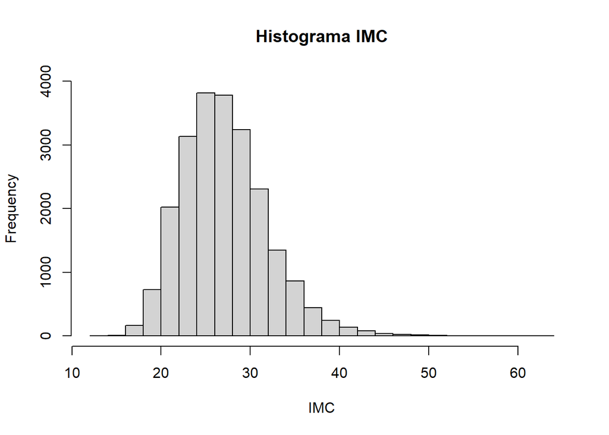

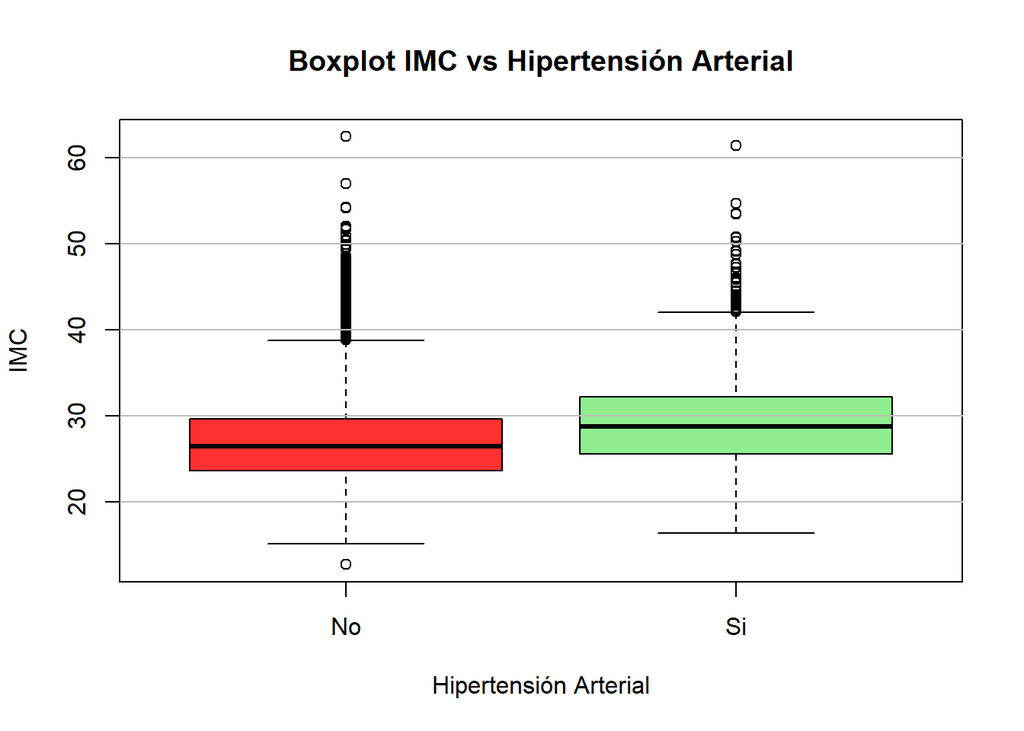

# Prueba de hipótesis

Media del IMC de las personas que tienen y no tienen Hipertensión arterial = 27.15:

```r
U
```

```
## [1] 27.15297
```

Nota: “A” es creado a partir del DN, tomando solo la variable IMC e Hipertensión arterial

En base a la media encontrada anteriormente se plantean las siguentes hipótesis:

$H_0:$ El IMC del las personas que tienen hipertensión arterial es mayor o igual a 27.15

$H_a$ El IMC del las personas que tienen hipertensión arterial es menor a 27.15

$$H_0: \mu \geq27.15\\
H_a:\mu<27.15\\
\alpha = 0.05$$

Tamaño de la muestra:

```
## [1] 1892
```

Estadístico de prueba:
$$t=\frac{\bar{x}-\mu_0}{s/\sqrt(n)}$$

```
## [1] 16.92617
```

Valor crítico:

```
## [1] -1.64566
```

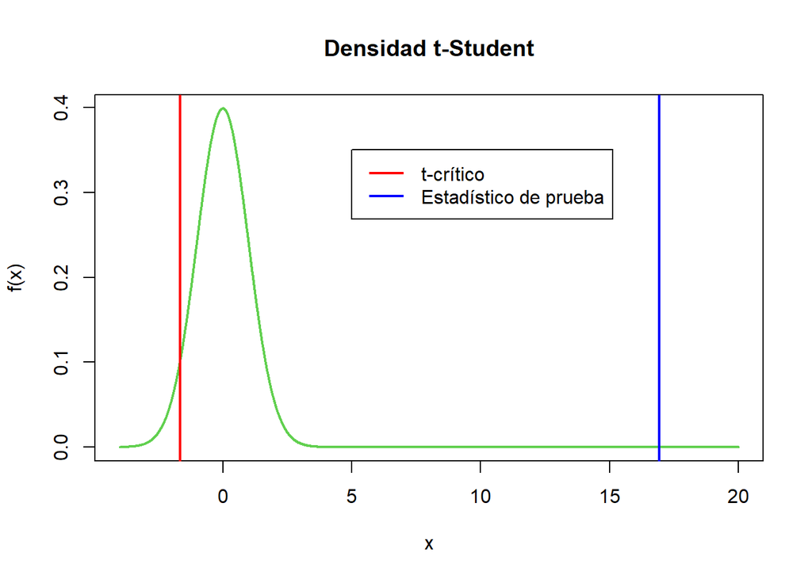

```
## [1] 1
```

## Intervalos de confianza

- IMC

```
## [1] "Límite inferior:"
```

```
## [1] 27.11514
```

```
## [1] "Límite superior:"
```

$∞$

Conclusión: Encontrado el t-crítico = -1.65, el valor del estadístico de prueba es igual a 16.92 y analizando el gráfico anterior notamos que el estadístico se encuentra en la zona de aceptación. Contrastando este análisis con el valor-p obtenida, concluimos que no encontramos suficiente evidencia estadística para rechazar $H_0$, para una significancia del 5%.

## *————————————————————————————————–*

# Edad

- Edad, esta variable es crucial en el análisis para la predicción de factores de riesgo cardiovascular, dado que en el Perú según los estudios TORNASOL, la prevalencia de hipertensión arterial es de 46,3% en personas con edad en la década entre 60 y 69; 53,2% en la década entre 70 a 79 años y de 56,3% en los mayores de 80 años.

```
##    Min. 1st Qu.  Median    Mean 3rd Qu.    Max.    NA's
##   15.00   27.00   37.00   40.11   52.00   97.00    1769
```

- Media

```
## [1] 40.11341
```

- Mediana

```
## [1] 37
```

- IQR

```
## [1] 25
```

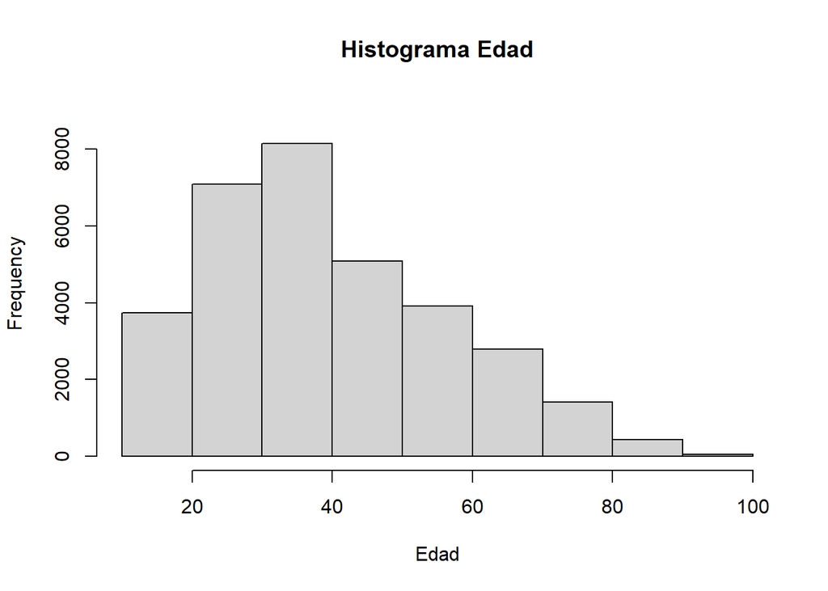

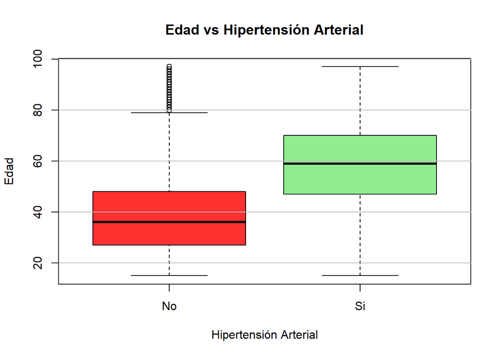

Según este gráfico podemos observar una mayor presencia de personas con Hipertensión Arterial o Presión alta después de los 50 años, según el [Texas Heart Institute](https://www.texasheart.org/heart-health/heart-information-center/topics/presion-arterial-alta-hipertension-arterial/), las personas que tienen más de 60 años son más propensos a sufrir de Hipertensión Arterial. Esto debido a que los vasos sanguíneos se debilitan con los años y pierden su elasticidad.

# Prueba de hipótesis

Media de la Edad de las personas que tienen y no tienen hipertensión arterial es = 40.1

En base a la media encontrada anteriormente se plantean las siguentes hipótesis:

$H_0:$ La edad de las personas que tienen hipertensión arterial es mayor o igual a 40.1

$H_a$ La edad de las personas que tienen hipertensión arterial es menor a 40.1

$$H_0: \mu \geq 40.1\\
H_a:\mu<40.1\\
\alpha = 0.05$$

Tamaño de la muestra:

```
## [1] 2762
```

Estadístico de prueba:
$$t=\frac{\bar{x}-\mu_0}{s/\sqrt(n)}$$

```
## [1] 57.98201
```

Valor crítico:

```
## [1] -1.645406
```

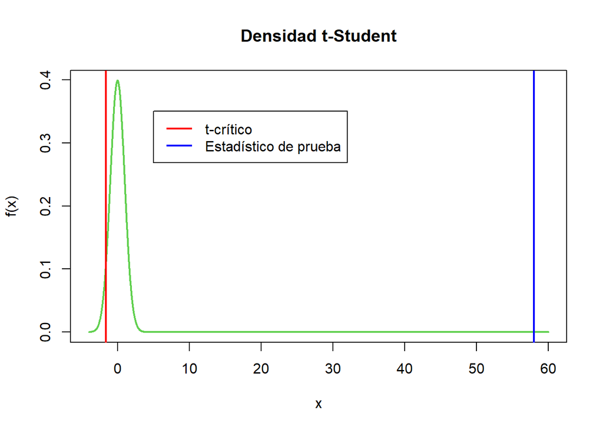

```
## [1] 1
```

```
## [1] "Límite inferior:"
```

```
## [1] 40.07054
```

```
## [1] "Límite superior:"
```

$∞$

Conclusión: Encontrado el t-crítico = -1.65, el valor del estadístico de prueba es igual a 57.98 y analizando el gráfico anterior notamos que el estadístico se encuentra en la zona de aceptación. Contrastando este análisis con el valor-p obtenida, concluimos que no encontramos suficiente evidencia estadística para rechazar $H_0$, para una significancia del 5%.

## *————————————————————————————————–*

# Consumo de frutas

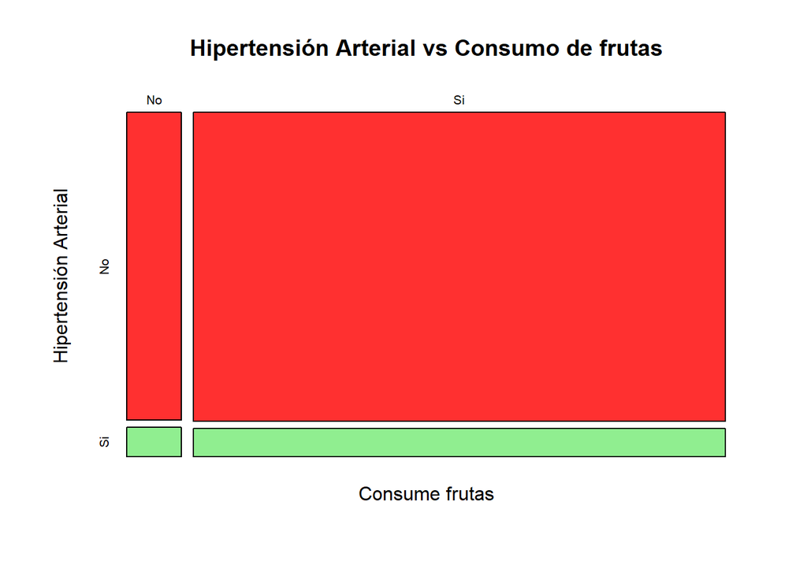

- Consumo de fruta por semana (Hábitos alimenticios saludables), con respecto a esta variable se consideró conveniente incorporarla en el estudio ya que se busca una mayor precisión en la predicción tratando de incluir todos los factores influyentes, ya que es una premisa popular es que los hábitos de alimentación influyen en la prevención o no de las enfermedades.

# Prueba de hipótesis

Para esta hipótesis se considero que la media de la cantidad de días que consumió frutas por persona es de al menos 4.65 días a la semana con una significancia de $\alpha=0,05$ y un numero de datos de 4531. Por consiguiente, es una hipótesis unilateral izquierda (H0: u>=4.65, H1: u<4.65) y se puede decir que se ajusta a una distribución normal debido al número datos.

$$h_0: \mu \geq 4.65 \\
h_a: \mu < 4.65$$

```
## [1] "Tamaño de la muestra"
```

```
## [1] 4531
```

```
## [1] "Media"
```

```
## [1] 4.646704
```

```
## [1] "Estadístico de prueba:"
```

```
## [1] -0.09906551
```

```
## [1] "P-valor:"
```

```
## [1] 0.5394569
```

```
## [1] "Z Crítico:"
```

```
## [1] -1.644854
```

- Cantidad de fruta consumida en la semana

```
## [1] "Límite inferior:"
```

```
## [1] 4.14643
```

```
## [1] "Límite superior:"
```

$∞$

## *————————————————————————————————–*

# Regresión

Nuestro estudio al tratarse de un algoritmo de predicción, busca patrones relacionales entre las variables, por ello se plantea un análisis entre las variables IMC y perímetro abdominal para determinar si su correlación se ajusta a un modelo de regresión lineal.

Vamos a analizar dos variables para comprobar si estas tienen correlación y se ajustará un modelo de regresión lineal.

Realizamos un análisis visual de las dos variables:

```
## [1] "Correlación:"
```

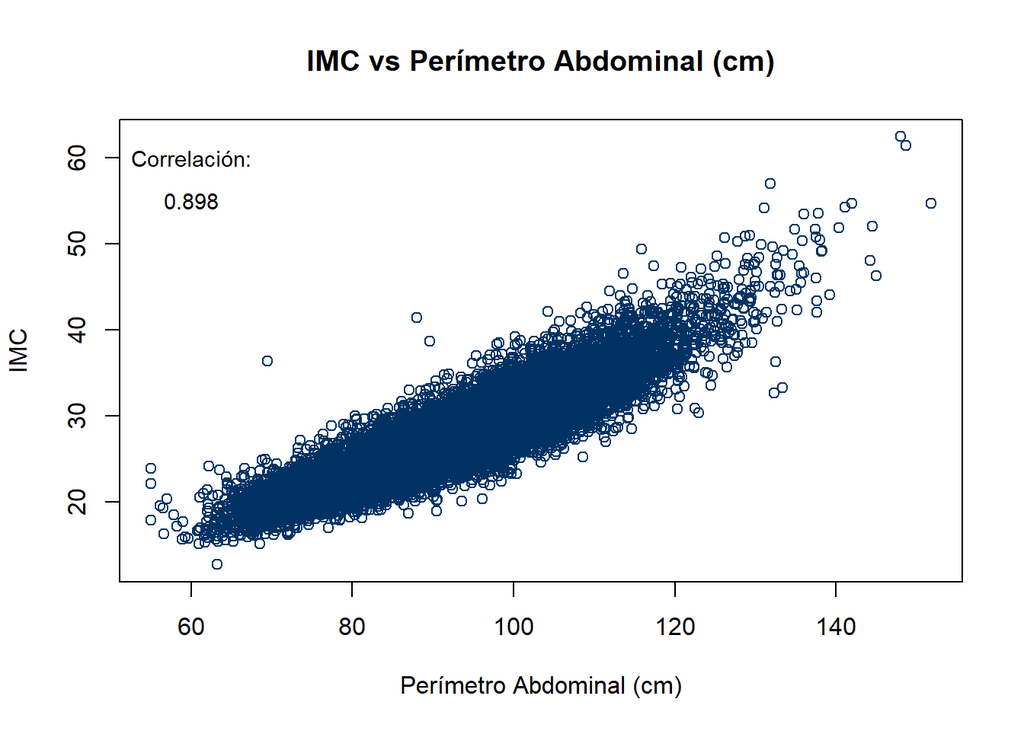

De este gráfico podemos observar a simple vista que existe una relación entre ambas variables, teniendo un comportamiento lineal y obteniendo una correlación de 0.898.

Ajustamos un modelo de regresión lineal para explicar el IMC en función del Perímetro Abdominal en cm de una persona.

```
##
## Call:
## lm(formula = IMC ~ Perimetro_abdominal_cm, data = DN2narm)
##
## Residuals:
##     Min      1Q  Median      3Q     Max
## -9.3484 -1.3700 -0.0925  1.2529 17.2249
##
## Coefficients:
##                         Estimate Std. Error t value Pr(>|t|)
## (Intercept)            -6.220706   0.111410  -55.84   <2e-16 ***
## Perimetro_abdominal_cm  0.364544   0.001208  301.85   <2e-16 ***
## ---
## Signif. codes:  0 '***' 0.001 '**' 0.01 '*' 0.05 '.' 0.1 ' ' 1
##
## Residual standard error: 2.11 on 21817 degrees of freedom
## Multiple R-squared:  0.8068, Adjusted R-squared:  0.8068
## F-statistic: 9.111e+04 on 1 and 21817 DF,  p-value: < 2.2e-16
```

La ecuación de la recta ajustada es:

$\hat{IMC} = -6.220706+0.364544~(\hat{Perímetro~abdominal})$

El coeficiente de determinación es 0.8068. Este coeficiente nos indica el grado de ajuste de la recta de regresión a los valores de la muestra. En nuestro caso, obtenemos un ajuste bueno.

Agregamos al gráfico la recta de regresión estimada:

```
## [1] "Recta de regresión:"
```

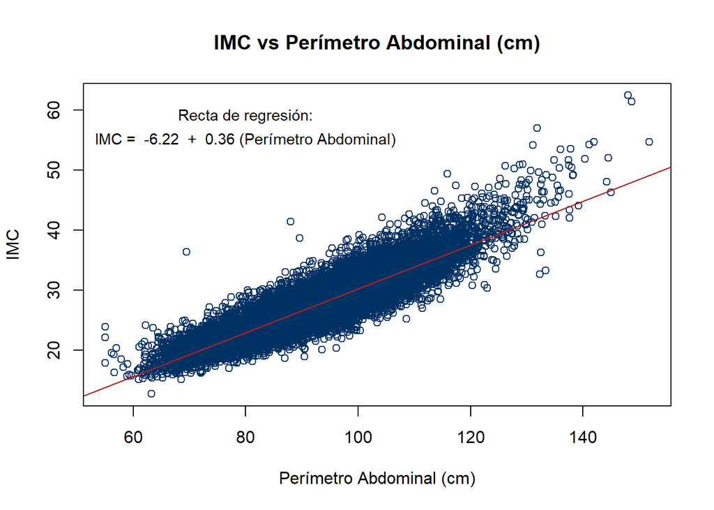

**Análisis de los residuos**

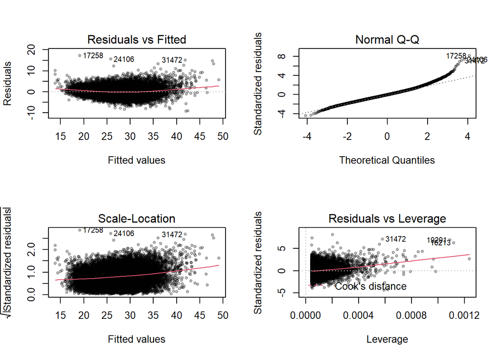

Apliquemos el test de Breush-Pagan, cuya hipótesis nula es la homocedasticidad (varianza de los errores es constante). La regla de decisión indica que si el nivel de significancia es mayor que el p-valor, entonces, existe homocedasticidad.

```
##
##  studentized Breusch-Pagan test
##
## data:  regresion_simple
## BP = 995.21, df = 1, p-value < 2.2e-16
```

- Análisis de Normal Q-Q

Del gráfico q-q, observamos el efecto los outliers, hacen que la normalidad de los errores no sea clara. Ahora, aplicaremos el test de Shapiro-Wild, para confirmar lo que hemos observado

```
##
##  Shapiro-Wilk normality test
##
## data:  base_rg_err2$regresion_simple2.residuals
## W = 0.98945, p-value < 2.2e-16
```

El test de Shapiro, tiene como hipótesis nula la normalidad de la distribución

Escogemos un nivel de significancia del 5%, que es mayor que el p-valor del test, por lo que RECHAZAMOS la hipótesis nula; es decir, los errores no se distribuyen normalmente. Esto se debe al efecto de los outliers

- Análisis de Residual vs Leverage

Se puede observar que existen algunos puntos que producen el efecto palanca y los cuales podrían ser determinantes de la tendencia.

Veamos si esos puntos atípicos son puntos influyentes en el modelo con el gráfico de distancia de Cook.

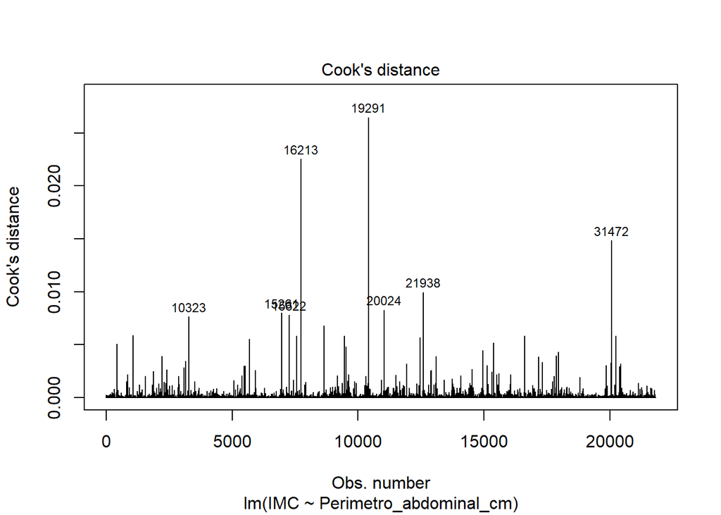

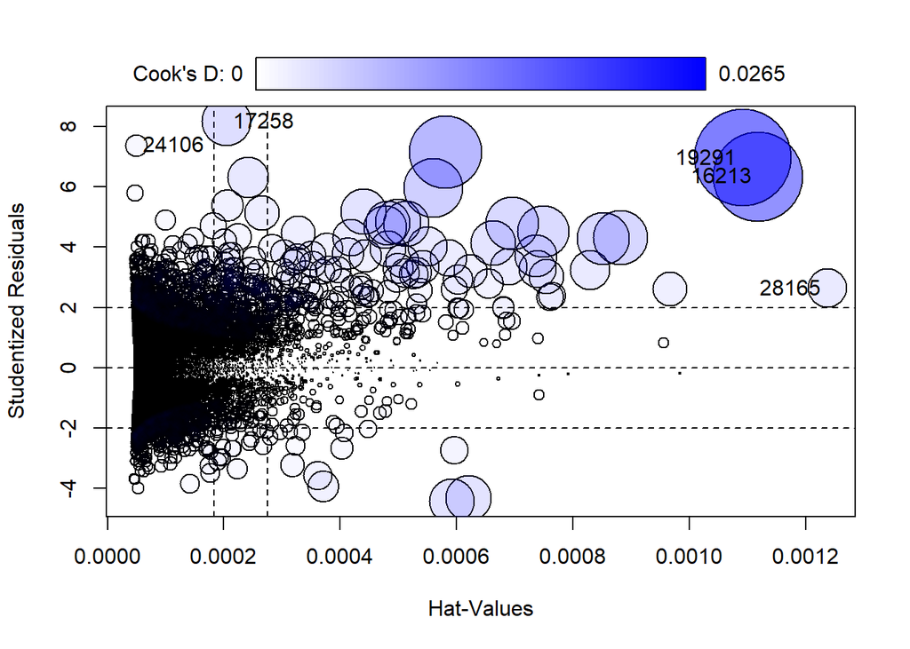

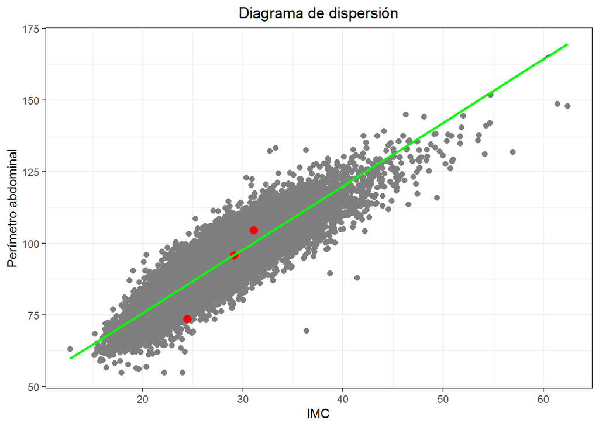

Gráficamente parece no existir diferencia. Comparemos los coeficientes del modelo con los del modelo sin los puntos de influencia.

```
##
## Call:
## lm(formula = IMC ~ Perimetro_abdominal_cm, data = DN2narm[-ind_inf,
##     ])
##
## Residuals:
##     Min      1Q  Median      3Q     Max
## -9.3493 -1.3702 -0.0927  1.2529 17.2256
##
## Coefficients:
##                         Estimate Std. Error t value Pr(>|t|)
## (Intercept)            -6.223192   0.111418  -55.85   <2e-16 ***
## Perimetro_abdominal_cm  0.364569   0.001208  301.85   <2e-16 ***
## ---
## Signif. codes:  0 '***' 0.001 '**' 0.01 '*' 0.05 '.' 0.1 ' ' 1
##
## Residual standard error: 2.11 on 21814 degrees of freedom
## Multiple R-squared:  0.8068, Adjusted R-squared:  0.8068
## F-statistic: 9.111e+04 on 1 and 21814 DF,  p-value: < 2.2e-16
```

El modelo de regresión ajustado sin los puntos de influencia es:

$\hat{IMC} = -6.223192+0.364569~(\hat{Perímetro~abdominal})$

El modelo de regresión con los puntos es:

$\hat{IMC} = -6.220706+0.364544~(\hat{Perímetro~abdominal})$

Se puede apreciar que estos son casi iguales con un coeficiente de determinación de 0.8068 para ambos casos.

Conclusión: A pesar de haber ajustado el modelo lineal excluyendo los puntos de influencia, este no varió mucho del original, puesto que estos puntos son pocos en comparación al resto de puntos.

## *————————————————————————————————–*

# Conclusiones Finales

Del estudio realizado, a través del análisis descriptivo y predictivo, nos permitió alcanzar el objetivo planteado al inicio de nuestro proyecto.

# Gracias :D